# Regresyon Ödevi

Muhammet Fatih ANAÇ

2023-11-13

## Gerekli Paketler

```r
library(base)
library(graphics)
library(ggplot2)
library(dplyr)
library(broom)
library(ggpubr)
library(ISLR)
library(PerformanceAnalytics)
```

## Verinin Tanıtılması

Betonun dayanıklılığını(Strength); çimento =Cement, yüksek fırın cürufu = Blast.Furnace.Slag, uçucu kül=FlyAsh, su=water, iri agregalar kum = Coarse.Aggregate, ince agregalar kum = fine aggregate, yaş = age değişkenlerinin ne kadar etkilediğini görmek için çoklu doğrusal regresyon uygulaması yapacağım.

Strength degiskeni bagimli degisken; Cement, Blast.Furnace.Slag, FlyAsh, water, Coarse.Aggregate, fine aggregate, ve age değişkenleri bağımsız değişkendir.

```r
veriseti<-read.csv("C:/Users/m.fatih/OneDrive/Masaüstü/Regresyon Veriseti/concrete_data.csv")
View(veriseti)
summary(veriseti)
```

```
##      Cement      Blast.Furnace.Slag    Fly.Ash          Water
##  Min.   :102.0   Min.   :  0.00     Min.   :  0.0   Min.   : 90.2
##  1st Qu.:192.0   1st Qu.:  0.00     1st Qu.:  0.0   1st Qu.:164.9
##  Median :272.8   Median : 22.00     Median :  0.0   Median :185.0
##  Mean   :280.7   Mean   : 74.63     Mean   : 54.5   Mean   :182.9
##  3rd Qu.:350.0   3rd Qu.:144.93     3rd Qu.:118.3   3rd Qu.:192.0
##  Max.   :540.0   Max.   :359.40     Max.   :200.1   Max.   :785.0
##  NA's   :2       NA's   :1          NA's   :1       NA's   :2
##  Superplasticizer  Coarse.Aggregate Fine.Aggregate        Age
##  Min.   :  0.000   Min.   :  15.0   Min.   :  91.0   Min.   :  1.00
##  1st Qu.:  0.000   1st Qu.: 932.0   1st Qu.: 730.4   1st Qu.:  7.00
##  Median :  6.450   Median : 968.0   Median : 779.3   Median : 28.00
##  Mean   :  6.481   Mean   : 970.2   Mean   : 772.5   Mean   : 46.77
##  3rd Qu.: 10.300   3rd Qu.:1029.4   3rd Qu.: 824.0   3rd Qu.: 56.00
##  Max.   :145.000   Max.   :1145.0   Max.   :1000.0   Max.   :799.80
##  NA's   :5         NA's   :6        NA's   :2        NA's   :1
##     Strength
##  Min.   : 2.33
##  1st Qu.:23.69
##  Median :34.40
##  Mean   :35.79
##  3rd Qu.:45.90
##  Max.   :82.60
##  NA's   :6
```

Öncelikle değişkenler arasındaki ilişkiyi korelasyon yardımıyla görelim:

```r
cor(veriseti)
```

```
##                    Cement Blast.Furnace.Slag Fly.Ash Water Superplasticizer
## Cement                  1                 NA      NA    NA               NA
## Blast.Furnace.Slag     NA                  1      NA    NA               NA
## Fly.Ash                NA                 NA       1    NA               NA
## Water                  NA                 NA      NA     1               NA
## Superplasticizer       NA                 NA      NA    NA                1
## Coarse.Aggregate       NA                 NA      NA    NA               NA
## Fine.Aggregate         NA                 NA      NA    NA               NA
## Age                    NA                 NA      NA    NA               NA
## Strength               NA                 NA      NA    NA               NA
##                    Coarse.Aggregate Fine.Aggregate Age Strength
## Cement                           NA             NA  NA       NA
## Blast.Furnace.Slag               NA             NA  NA       NA
## Fly.Ash                          NA             NA  NA       NA
## Water                            NA             NA  NA       NA
## Superplasticizer                 NA             NA  NA       NA
## Coarse.Aggregate                  1             NA  NA       NA
## Fine.Aggregate                   NA              1  NA       NA
## Age                              NA             NA   1       NA
## Strength                         NA             NA  NA        1
```

Eksik gözlemler olduğu için göremedik.

```r
sum(is.na(veriseti))
```

```
## [1] 26
```

Veride 26 tane eksik gözlem olduğu görülüyor.

Eksik gözlemlerin indekslerini öğrenmek istersek:

```r
which(is.na(veriseti)==T)
```

```
##  [1]  524  848 2062 3093 3194 3350 4415 4848 4964 4972 5118 5446 5843 5879 5995
## [16] 6003 6149 6443 7026 7965 8539 8936 8972 8996 9088 9242
```

Veri seti içerisinden, eksik gözlem(NA) olan gözlemleri silip değişkenler arasındaki ilişkiyi korelasyon yardimiyla gorelim:

```r
cor(na.omit(veriseti))
```

```
##                         Cement Blast.Furnace.Slag      Fly.Ash       Water
## Cement              1.00000000         -0.2740610 -0.398648309 -0.08178193
## Blast.Furnace.Slag -0.27406104          1.0000000 -0.322971633  0.10502158
## Fly.Ash            -0.39864831         -0.3229716  1.000000000 -0.25346916
## Water              -0.08178193          0.1050216 -0.253469160  1.00000000
## Superplasticizer    0.09278699          0.0429285  0.377195261 -0.65692523
## Coarse.Aggregate   -0.11037806         -0.2825911 -0.009441349 -0.18732363
## Fine.Aggregate     -0.22347461         -0.2817016  0.076278959 -0.44763299
## Age                 0.08428956         -0.0453693 -0.155050901  0.27834635
## Strength            0.49965584          0.1349520 -0.108509170 -0.28798439
##                    Superplasticizer Coarse.Aggregate Fine.Aggregate
## Cement                   0.09278699     -0.110378063    -0.22347461
## Blast.Furnace.Slag       0.04292850     -0.282591143    -0.28170161
## Fly.Ash                  0.37719526     -0.009441349     0.07627896
## Water                   -0.65692523     -0.187323626    -0.44763299
## Superplasticizer         1.00000000     -0.262858841     0.21950925
## Coarse.Aggregate        -0.26285884      1.000000000    -0.17507968
## Fine.Aggregate           0.21950925     -0.175079676     1.00000000
## Age                     -0.19219831     -0.002667781    -0.15696943
## Strength                 0.36550275     -0.160284546    -0.17154505
##                             Age   Strength
## Cement              0.084289562  0.4996558
## Blast.Furnace.Slag -0.045369296  0.1349520
## Fly.Ash            -0.155050901 -0.1085092
## Water               0.278346350 -0.2879844
## Superplasticizer   -0.192198315  0.3655027
## Coarse.Aggregate   -0.002667781 -0.1602845
## Fine.Aggregate     -0.156969435 -0.1715451
## Age                 1.000000000  0.3297702
## Strength            0.329770163  1.0000000
```

Korelasyon matrisi incelendiğinde bağımlı değişken olan ‘Strength’ değişkeni ile dört bağımsız değişkenin pozitif yönlü ilişkisi, diğer dört bagımsız değişkenin de negatif yönlü ilişkisi olduğu görülüyor. Korelasyon matrisine bakıldığında, bazı bağımsız değişkenlerin arasinda ilişki olduğu görülüyor.

Değişkenler arasındaki ilişkiyi görsel yardımıyla görmek istersek:

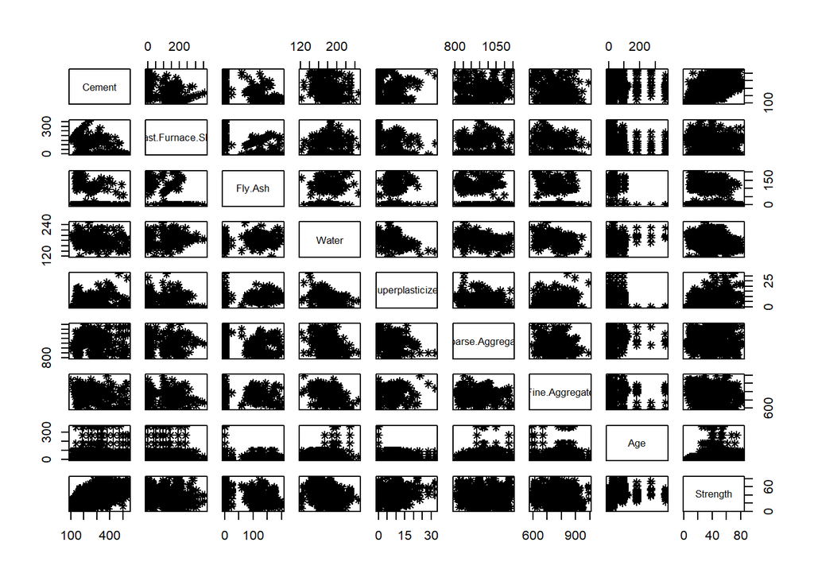

```r
pairs(na.omit(veriseti),pch=8)
```

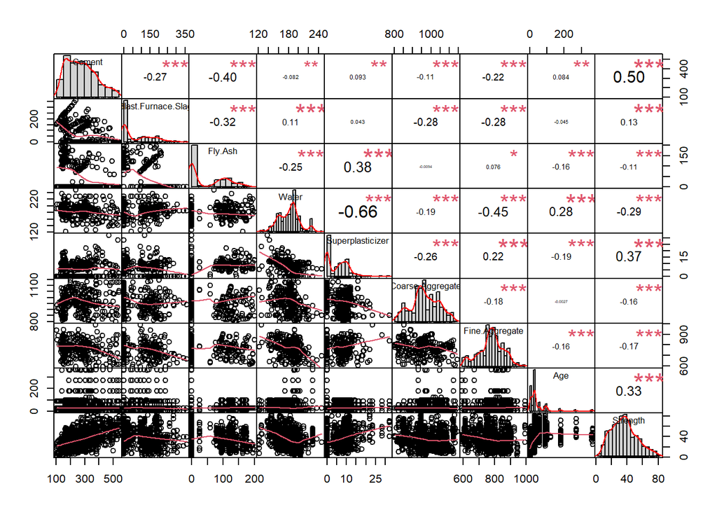

```r
chart.Correlation(na.omit(veriseti),pch=8,histogram = TRUE)
```

## Kayıp Gözlemler

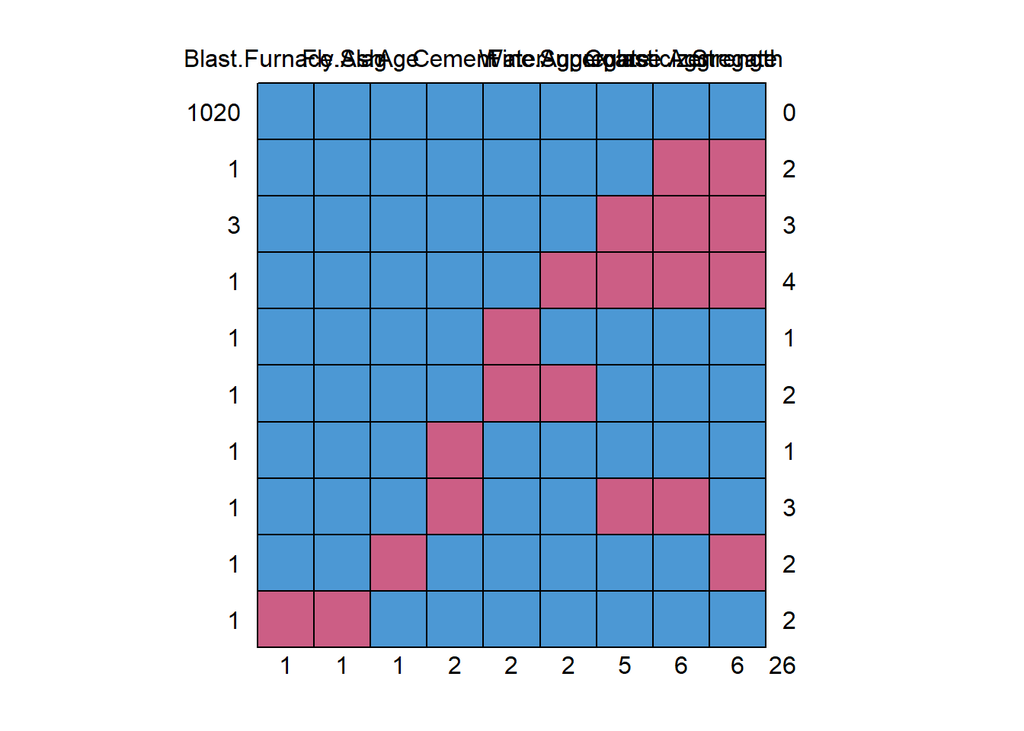

```
##      Blast.Furnace.Slag Fly.Ash Age Cement Water Fine.Aggregate
## 1020                  1       1   1      1     1              1
## 1                     1       1   1      1     1              1
## 3                     1       1   1      1     1              1
## 1                     1       1   1      1     1              0
## 1                     1       1   1      1     0              1
## 1                     1       1   1      1     0              0
## 1                     1       1   1      0     1              1
## 1                     1       1   1      0     1              1
## 1                     1       1   0      1     1              1
## 1                     0       0   1      1     1              1
##                       1       1   1      2     2              2
##      Superplasticizer Coarse.Aggregate Strength
## 1020                1                1        1  0
## 1                   1                0        0  2
## 3                   0                0        0  3
## 1                   0                0        0  4
## 1                   1                1        1  1
## 1                   1                1        1  2
## 1                   1                1        1  1
## 1                   0                0        1  3
## 1                   1                1        0  2
## 1                   1                1        1  2
##                     5                6        6 26
```

```r
library(mice)
md.pattern(veriseti)
```

Verideki 1020 gözlemde NA değeri olmadığını ve toplamda 26 NA değeri olduğunu görüyoruz.

## Eksik Gözlemleri Doldurma İşlemi

```r
help(mice)
imputed<-mice(veriseti, m=5)
imputed$imp
```

```
## $Cement
##         1     2     3     4     5
## 524 139.6 139.6 165.0 167.4 157.0
## 848 139.6 300.0 190.3 424.0 139.6
##
## $Blast.Furnace.Slag
##      1 2 3   4 5
## 1031 0 0 0 128 0
##
## $Fly.Ash
##          1    2     3 4     5
## 1031 100.4 94.1 159.9 0 125.2
##
## $Water
##         1     2   3     4   5
## 101 401.0 101.0 228 228.0 101
## 257 203.5 137.8 192 197.9 190
##
## $Superplasticizer
##     1 2 3 4 5
## 291 0 0 0 0 0
## 724 0 0 0 0 0
## 840 0 0 0 0 0
## 848 3 0 0 0 0
## 994 0 0 0 6 0
##
## $Coarse.Aggregate
##          1      2      3      4      5
## 291  144.0   15.0  882.0   15.0  899.0
## 688 1058.7 1098.0 1058.7 1058.7 1058.7
## 724  144.0  882.0  882.0  882.0  882.0
## 840  882.0  852.1  882.0   99.0   99.0
## 848  882.0   99.0   15.0   99.0  882.0
## 994   15.0  882.0   99.0   99.0  882.0
##
## $Fine.Aggregate
##       1   2   3     4     5
## 257 945 945 945 945.0 945.0
## 840 613  91  91 806.9 756.9
##
## $Age
##     1  2  3 4 5
## 748 3 28 28 3 3
##
## $Strength
##         1     2     3     4     5
## 291 25.18 13.20 67.11  4.57 47.10
## 688  4.57  7.84  7.84 23.90  2.33
## 724 21.75 65.20 74.17 35.75 41.10
## 748 55.90 34.90 56.14 56.62 78.80
## 840 75.50 27.04 16.50  8.54 30.96
## 994  9.31 71.70 27.04 13.20 25.42
```

m=5, iterasyon sayisini temsil ediyor. Yani biz bu adımda, her bir değişkende buluna NA degerlerini dolduracagimiz imput degeri hesaplatiyoruz. m=5 verdigimiz icin bu degerleri her bir degisken icin 5 kere olusturuyor. Elde edilen bu degerlerden herhangi birini secip eksik gozlemleri doldurabiliriz. Istegimize bagli olarak bu degerlerin ortalamasini veya medyanini da kullanabiliriz. Ben bu adimda, 4. degerler ile doldurmayi tercih ettim.

```r
veriseti_impt<-complete(imputed,4)
View(veriseti_impt)
sum(is.na(veriseti))
```

```
## [1] 26
```

```r
sum(is.na(veriseti_impt))
```

```
## [1] 0
```

```
##  /\     /\
## {  `---'  }
## {  O   O  }
## ==>  V <==  No need for mice. This data set is completely observed.
##  \  \|/  /
##   `-----'
```

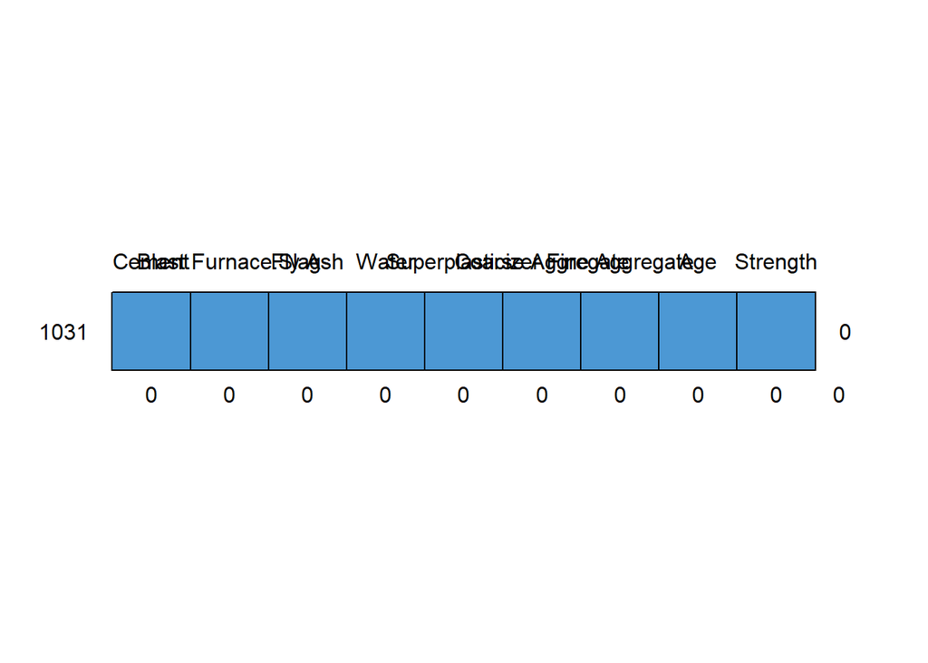

```
##      Cement Blast.Furnace.Slag Fly.Ash Water Superplasticizer Coarse.Aggregate
## 1031      1                  1       1     1                1                1
##           0                  0       0     0                0                0
##      Fine.Aggregate Age Strength
## 1031              1   1        1 0
##                   0   0        0 0
```

```r
md.pattern(veriseti_impt)
```

Veride eksik gözlem kalmadığını doğruladım.

## Veriyi, Eğitim Verisi ve Test Verisi Olarak Ayırma

Verimiz model oluşturmaya hazır hale geldi. İlk olarak veriyi %80 eğitim verisi %20 test verisi olarak ayırdım.

```r
set.seed(123)
orneklem_indeks<-sample(1:nrow(veriseti_impt),size=0.8*nrow(veriseti_impt))
orneklem_indeks
```

```
##   [1]  415  463  179  526  195  938  665  602  603  768  709 1011   91  953  348
##  [16]  649  989  355  840   26  519  426 1016  766  211  932  590  593  555  871
##  [31]  373  844  143  544  490  621  775  905  937  842   23  923  956  309  135
##  [46]  821  990  224  166  217  290  581   72  588  575  141  722  865  859  153
##  [61]  294  277 1030   41  431   90  316  223  528  116  606  774  747  456  598
##  [76]  854   39  159  752  209  374  818   34  516   13   69  895  755  409  308
##  [91]  278   89  928  537  291  424  880  286  908  671  121  110  158   64  483
## [106]  910  477  480  711   67  663  890  847   85  165  648   51   74  178  362
## [121]  236  610  330  726  127  212  686  785  814  310  744  878  243  862  919
## [136]  792  113  619  925  151  666  614  767  160  391  155 1010    5  326  784
## [151]  280  800  789  567  843  238  764  339  955  822  137  455  738  560  589
## [166]   83  696  873  196  769  680  934  961  500  882  344  902  459   20 1027
## [181]  164   52  534  177  554  827   84  523  633  392  302  597  706  894  867
## [196]  430  710  761  712  428  672  250  804  429  398  963  381  545   40  522
## [211]  473  200  125  265  995  186  573  252  458  152   54  538  235  289  185
```

[output cut: 40 more lines]

```r
trainset<-veriseti_impt[orneklem_indeks,]
testset<-veriseti_impt[-orneklem_indeks,]
View(trainset)
View(testset)
nrow(trainset)*ncol(trainset)
```

```
## [1] 7416
```

```r
nrow(testset)*ncol(testset)
```

```
## [1] 1863
```

```r
names(veriseti_impt)
```

```
## [1] "Cement"             "Blast.Furnace.Slag" "Fly.Ash"
## [4] "Water"              "Superplasticizer"   "Coarse.Aggregate"
## [7] "Fine.Aggregate"     "Age"                "Strength"
```

## Molde Oluşturma

```r
model1<-lm(Strength~Cement+Blast.Furnace.Slag+Fly.Ash+Water+Superplasticizer+Coarse.Aggregate+Fine.Aggregate
           +Age,data = trainset)
model1
```

```
##
## Call:
## lm(formula = Strength ~ Cement + Blast.Furnace.Slag + Fly.Ash +
##     Water + Superplasticizer + Coarse.Aggregate + Fine.Aggregate +
##     Age, data = trainset)
##
## Coefficients:
##        (Intercept)              Cement  Blast.Furnace.Slag             Fly.Ash
##         -1.148e+02           1.507e-01           1.294e-01           1.358e-01
##              Water    Superplasticizer    Coarse.Aggregate      Fine.Aggregate
##          8.601e-03           7.045e-02           4.918e-02           4.828e-02
##                Age
##          9.054e-02
```

```r
summary(model1)
```

```
##
## Call:
## lm(formula = Strength ~ Cement + Blast.Furnace.Slag + Fly.Ash +
##     Water + Superplasticizer + Coarse.Aggregate + Fine.Aggregate +
##     Age, data = trainset)
##
## Residuals:
##     Min      1Q  Median      3Q     Max
## -66.140  -6.893   0.379   7.095  38.333
##
## Coefficients:
##                      Estimate Std. Error t value Pr(>|t|)
## (Intercept)        -1.148e+02  1.910e+01  -6.012 2.76e-09 ***
## Cement              1.507e-01  6.822e-03  22.084  < 2e-16 ***
## Blast.Furnace.Slag  1.294e-01  8.431e-03  15.351  < 2e-16 ***
## Fly.Ash             1.358e-01  1.053e-02  12.901  < 2e-16 ***
## Water               8.601e-03  2.511e-02   0.343    0.732
## Superplasticizer    7.045e-02  7.620e-02   0.924    0.356
## Coarse.Aggregate    4.918e-02  7.790e-03   6.313 4.49e-10 ***
## Fine.Aggregate      4.828e-02  8.018e-03   6.021 2.62e-09 ***
## Age                 9.054e-02  6.074e-03  14.906  < 2e-16 ***
## ---
## Signif. codes:  0 '***' 0.001 '**' 0.01 '*' 0.05 '.' 0.1 ' ' 1
##
## Residual standard error: 10.99 on 815 degrees of freedom
## Multiple R-squared:  0.5608, Adjusted R-squared:  0.5565
## F-statistic: 130.1 on 8 and 815 DF,  p-value: < 2.2e-16
```

Eğitim verisini kullanarak model oluşturdum. Modelde tüm değişkenleri kullandım.

## Anlamlı Olmayan Değişkenlerin Modelden Çıkarılıp Yeni Model Kurulması

```r
model2<-lm(Strength~Cement+Blast.Furnace.Slag+Fly.Ash+Coarse.Aggregate+Fine.Aggregate+Age, data=trainset)
model2
```

```
##
## Call:
## lm(formula = Strength ~ Cement + Blast.Furnace.Slag + Fly.Ash +
##     Coarse.Aggregate + Fine.Aggregate + Age, data = trainset)
##
## Coefficients:
##        (Intercept)              Cement  Blast.Furnace.Slag             Fly.Ash
##         -110.89120             0.15157             0.13044             0.13897
##   Coarse.Aggregate      Fine.Aggregate                 Age
##            0.04673             0.04813             0.09179
```

```r
summary(model2)
```

```
##
## Call:
## lm(formula = Strength ~ Cement + Blast.Furnace.Slag + Fly.Ash +
##     Coarse.Aggregate + Fine.Aggregate + Age, data = trainset)
##
## Residuals:
##     Min      1Q  Median      3Q     Max
## -60.536  -6.984   0.354   7.021  40.648
##
## Coefficients:
##                      Estimate Std. Error t value Pr(>|t|)
## (Intercept)        -1.109e+02  8.055e+00 -13.766   <2e-16 ***
## Cement              1.516e-01  5.276e-03  28.730   <2e-16 ***
## Blast.Furnace.Slag  1.304e-01  6.427e-03  20.295   <2e-16 ***
## Fly.Ash             1.390e-01  8.213e-03  16.920   <2e-16 ***
## Coarse.Aggregate    4.673e-02  4.284e-03  10.908   <2e-16 ***
## Fine.Aggregate      4.813e-02  5.227e-03   9.208   <2e-16 ***
## Age                 9.179e-02  5.906e-03  15.543   <2e-16 ***
## ---
## Signif. codes:  0 '***' 0.001 '**' 0.01 '*' 0.05 '.' 0.1 ' ' 1
##
## Residual standard error: 10.98 on 817 degrees of freedom
## Multiple R-squared:  0.5603, Adjusted R-squared:  0.557
## F-statistic: 173.5 on 6 and 817 DF,  p-value: < 2.2e-16
```

Modelleri karşılaştırmak için AIC ve BIC değerlerine bakılır. AIC ve BIC değerlerinin düşük çıkması tercih edilen durumdur.

```r
AIC(model1, k=10)
```

```
## [1] 6378.889
```

```r
AIC(model2,k=8)
```

```
## [1] 6343.816
```

```r
BIC(model1)
```

```
## [1] 6346.031
```

```r
BIC(model2)
```

```
## [1] 6333.529
```

Çok fark olmasa da model2’nin AIC ve BIC değerleri daha düşük çıktığı için model2 daha iyi diyebiliriz.

Model2’nin grafik sonuçları:

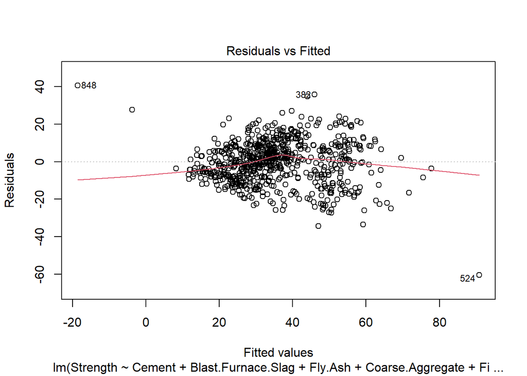

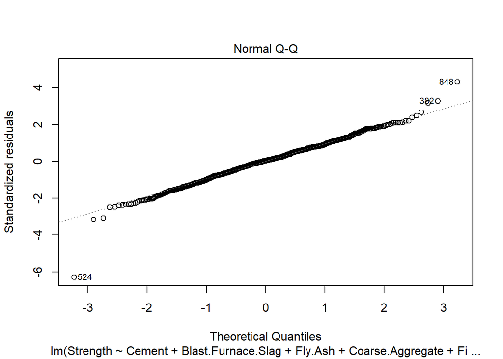

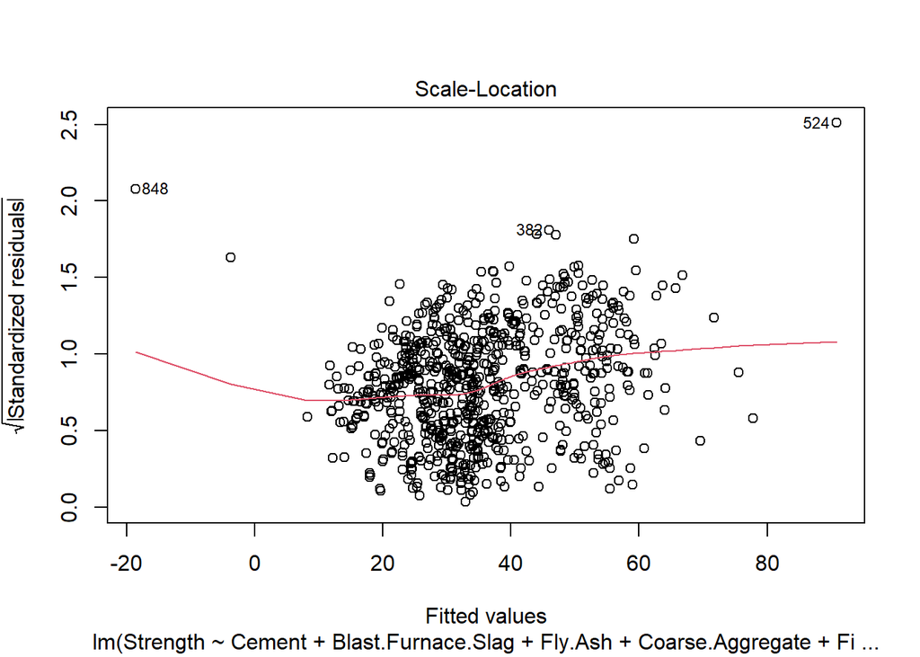

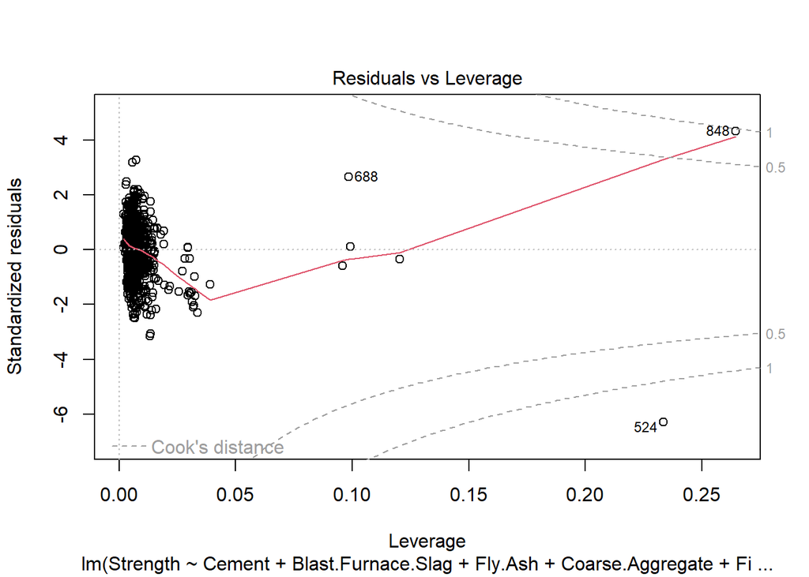

```r
plot(model2)
```

İlk grafikte artıkların dağılışını görüyoruz. 0 çizgisinde yatay bir görsel oluşmadığı için değişen varyanstan şüphelenebiliriz. Aykiri değerlerin de olabileceği görülüyor. İkinci grafikte artıkların normal dağılıp dağılmadığını inceliyoruz. Noktalarin tamamına yakininin cizgi üzerinde olduğu görülüyor. Birkaç gözlemin aykiri değer olabileceği de görülüyor. Üçüncü grafikte standardize edilmiş artıklar görülüyor. Bu grafikte de aykırı değerlerin olabileceği görülüyor. Dördüncü grafik baskınlık grafiğidir. Artıkların tamamına yakınının benzer etkiye sahip olduğu görülüyor. Cook’s distance çizgilerine bakıldığında ise modele olumsuz etki eden değerlerin olduğu görülüyor.

Değişen varyans durumunu test etmek icin Brusch-Pagan testini modelime uygulayacağım. Brusch-Pagan Testi: Test istatistiğinin uygun bir eşiğin altında bir p değeri varsa, o zaman eş varyanslılığın boş hipotezi reddedilir ve heteroskedastisite(degisen varyans var) varsayılır.

```r
library(lmtest)

bptest(model2)
```

```
##
##  studentized Breusch-Pagan test
##
## data:  model2
## BP = 128.99, df = 6, p-value < 2.2e-16
```

Brusch-Pagan testi sonucunda p-value degeri çok kuçuk çıktığı için HO:Heteroscedasticity is not present hipotezi reddedilir. Sabit varyans durumunun olmadığı Brusch-Pagan testi sonucunda görülür. Aykırı değer kontrolü yapılıp değişen varyans durumu tekrar kontrol edilmelidir.

## Model Değerlendirme Metricleri

Model2’yi olustururken anlamlı olmayan değişkenleri modelden çıkarmıştık. Öncelikle o değişkenlerin testset içerisinden çıkarılması gerekir:

```r
testset2<-testset[-c(4,5)]
testset2
```

```
##      Cement Blast.Furnace.Slag Fly.Ash Coarse.Aggregate Fine.Aggregate   Age
## 1     540.0                0.0     0.0           1040.0          676.0  28.0
## 3     332.5              142.5     0.0            932.0          594.0 270.0
## 7     380.0               95.0     0.0            932.0          594.0 365.0
## 12    198.6              132.4     0.0            978.4          825.5  28.0
## 14    190.0              190.0     0.0            932.0          670.0  90.0
## 15    304.0               76.0     0.0            932.0          670.0  28.0
## 22    139.6              209.4     0.0           1047.0          806.9  28.0
## 27    380.0               95.0     0.0            932.0          594.0 270.0
## 28    342.0               38.0     0.0            932.0          670.0 180.0
## 32    266.0              114.0     0.0            932.0          670.0 365.0
## 35    190.0              190.0     0.0            932.0          670.0 365.0
## 43    237.5              237.5     0.0            932.0          594.0 365.0
## 47    349.0                0.0     0.0           1047.0          806.9   3.0
## 60    332.5              142.5     0.0            932.0          594.0  28.0
```

[output cut: 401 more lines]

```r
predictions<-predict(model2,testset2)
predictions
```

```
##         1         3         7        12        14        15        22        27
## 54.662206 55.019730 64.743684 24.503300 26.752065 23.469577 27.915307 56.023346
##        28        32        35        43        47        60        62        63
## 38.225011 53.600936 51.995149 61.732835 30.044845 32.805816 44.880598 22.685167
##        66        70        73        75        86        92        97       101
## 46.486384 56.032381 50.181404 46.049949 48.752961 49.519191 50.455610 -3.164778
##       102       109       118       126       132       133       140       142
## 45.689167 49.120133 51.735587 55.039860 51.047787 51.814017 55.312276 55.046435
##       144       147       149       150       154       156       157       174
## 50.914980 55.046435 57.610065 55.046435 56.014548 54.384222 49.476385 55.692861
##       176       182       183       192       198       202       208       215
## 57.596978 61.734795 57.596978 25.532489 28.356668 27.643204 30.225994 25.103786
##       216       233       245       253       254       257       269       272
## 26.113509 30.447403 23.705184 31.606771 35.645665 19.476476 36.965782 30.547106
##       283       285       288       293       300       305       307       312
## 33.319880 26.851408 31.716439 31.766742 33.318425 32.572987 34.867813 35.768972
##       313       314       318       321       329       333       345       350
## 38.339176 42.378070 36.615571 30.827848 39.207068 38.375965 32.651621 32.452429
##       354       356       359       360       363       368       370       372
## 41.356353 35.846383 43.740584 35.204041 40.069072 35.748769 28.475905 30.770731
##       376       380       385       387       394       405       408       410
## 30.972365 53.659832 45.919523 49.353074 42.211185 49.121635 32.448247 32.531597
##       411       419       425       427       432       433       435       438
## 29.490617 29.001552 32.549081 34.142141 30.011276 26.996477 35.086659 33.834183
##       443       467       472       485       486       488       491       495
## 34.167420 33.404370 52.845086 55.415291 50.511066 50.511066 48.216240 53.081271
##       505       507       511       513       514       518       525       529
## 56.344509 61.209540 49.740079 49.372907 49.740079 23.970222 50.737632 48.809978
##       530       531       535       552       558       561       565       568
## 53.307837 53.307837 30.716377 15.097452 33.525556 29.470391 30.788930 25.133195
##       570       574       576       580       587       596       601       609
## 38.854608 45.905608 18.039098 27.060849 36.926954 23.502729 24.600496 20.970489
##       611       615       628       630       632       638       640       643
## 46.213573 25.789094 13.307137 15.958024 26.371850 31.578762 36.062442 20.441704
##       644       650       655       668       670       675       691       693
## 28.927876 26.227380 17.535301 36.262988 36.181153 27.137950 36.548325 29.519101
##       695       716       723       733       750       751       753       760
## 29.432776 27.878333 23.976952 30.933679 48.254610 49.539713 54.317346 27.544481
##       762       773       777       787       796       797       801       806
## 33.235649 32.145912 27.378503 27.257992 67.281464 55.230881 17.598654 37.346010
##       812       816       817       824       825       828       832       849
## 24.904383 51.034097 51.401269 38.456297 22.290557 53.864880 24.170759 31.623187
##       856       857       858       860       869       870       874       885
## 41.982324 40.247297 37.000415 24.722287 38.769649 33.959666 22.779724 29.894160
##       893       896       901       903       904       906       911       912
## 25.745876 35.564037 27.771843 40.521433 17.518931 18.862645 27.201725 21.157248
##       915       920       921       926       929       935       945       960
## 38.019741 25.413497 30.837549 31.345995 34.858765 30.307530 29.468485 39.428420
##       972       973       974       980       981       986       996       998
## 44.238248 21.656117 27.276142 32.689525 23.527207 32.971924 30.448482 38.714283
##      1000      1003      1007      1014      1018      1024      1025
## 23.592894 39.704327 20.430072 40.214497 35.810085 30.667579 30.640469
```

```r
length(predictions)
```

```
## [1] 207
```

```r
head(predictions)
```

```
##        1        3        7       12       14       15
## 54.66221 55.01973 64.74368 24.50330 26.75207 23.46958
```

Model2’den tahminler elde ettik. Şimdi metricler incelenirse:

```r
library(caret)
R2(predictions,testset2$Strength)
```

```
## [1] 0.5388243
```

```r
RMSE(predictions,testset2$Strength)
```

```
## [1] 12.08446
```

```r
MAE(predictions,testset2$Strength)
```

```
## [1] 9.456334
```

# Cook’s Distance

Öncelikle distance’ları belirlememiz gerekir. Sonra, hangi ölçütten sonrası bizim için aykırı değer olarak kabul edilecek ona karar verilir. Ölçüt belirlemede 2 farklı yöntem vardır:

1: Eğer herhangi bir distance bütün distance’ların ortalamasının 3 katından daha büyükse aykırı olabilir.

2: Eğer herhangi bir distance 4/tüm distance değerinden büyükse aykırı olabilir.

```r
distance<-cooks.distance(model2)

length(distance)
```

```
## [1] 824
```

```r
head(distance)
```

```
##          415          463          179          526          195          938
## 8.385975e-04 5.245559e-06 5.591047e-03 4.851391e-03 7.696734e-04 2.159388e-05
```

```r
olcut1<-mean(distance)*3
olcut2<-4/length(distance)

olcut1
```

```
## [1] 0.01367219
```

```r
olcut2
```

```
## [1] 0.004854369
```

İki ölçüt arasinda çok fazla fark olduğu görülüyor. Her iki ölçüt için de ayrı ayrı işlem yapıp aykırı gözlemlerin indekslerini elde edelim:

```r
olcut1Index<-which(distance>olcut1)
olcut2Index<-which(distance>olcut2)

olcut1Index
```

```
## 747  57 688 848 524 793 502   4  42
##  73 244 292 301 389 569 725 726 771
```

```r
olcut2Index
```

```
## 179 840 621 775  72 747  34 477  67  85 934 554 564  57 617 688 848 585 605 115
##   3  19  36  37  53  73  83 107 110 114 172 185 235 244 246 292 301 332 337 355
##  16 524 384 700 579  36 829 382 770 406 527 582 799 623 793 489 506 478 815 502
## 382 389 397 427 435 436 459 470 520 525 532 539 551 552 569 635 672 709 721 725
##   4 515  42  82 503 510 131
## 726 741 771 774 784 789 801
```

```r
length(olcut1Index);length(olcut2Index)
```

```
## [1] 9
```

```
## [1] 47
```

Sonuçlara bakıldıgında, olcut2’nin degeri olcut1’in değerinden oldukça küçük olduğu için olcut2’ye daha fazla aykırı değer tespit edilmiştir. Bundan sonraki adımlarda olcut2’yi tercih edip işlemlerime devam edeceğim. Aykırı değerleri bir de grafik üzerinde görmeye çalışırsak:

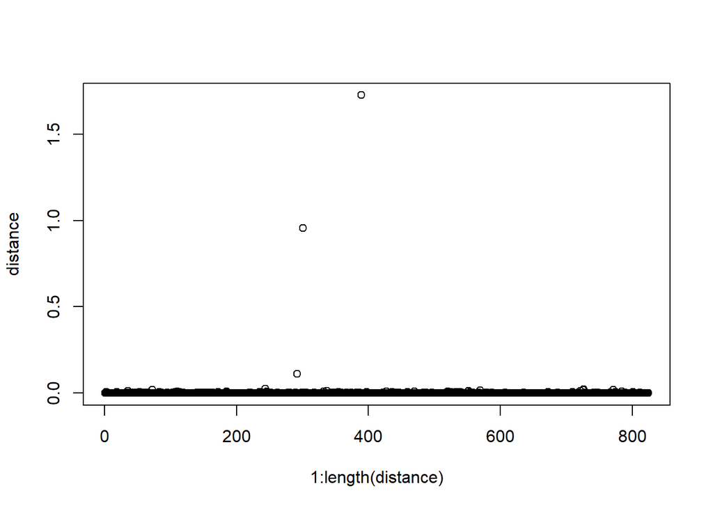

```r
plot(1:length(distance),distance,type="p")
```

Aykırı değerlerin olduğu görülüyor. Y ekseninin genişliğini biraz azaltıp daha detaylı incelersek:

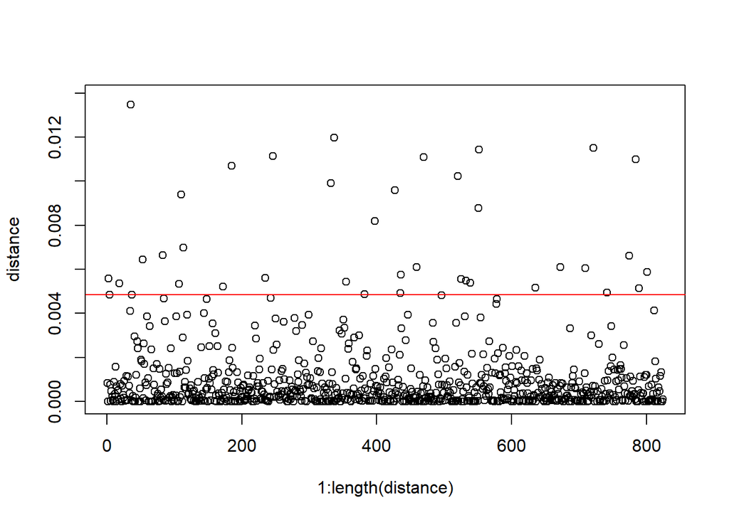

```r
plot(1:length(distance),distance,type="p",ylim=range(distance)*c(1,0.008))
abline(h=olcut2,col="red")
```

Olcut2’ye göre çizdirilen kırmızı çizginin üzerindeki değerler aykırı değerdir. Bu aykırı değerleri trainset içerisinden çıkaralım:

```r
trainsetrem<-trainset[-olcut2Index,]
nrow(trainset)
```

```
## [1] 824
```

```r
nrow(trainsetrem)
```

```
## [1] 777
```

```r
a<-nrow(trainsetrem)*ncol(trainsetrem)
b<-nrow(trainset)*ncol(trainset)
b-a
```

```
## [1] 423
```

## Model Karşılaştırılması

Aykırı değerleri çıkardığımız veri ile model3 oluşturup bu modeli, aykırı değerler çıkarılmadan oluşturulan model2 ile karşılaştıralım:

```r
names(trainsetrem)
```

```
## [1] "Cement"             "Blast.Furnace.Slag" "Fly.Ash"
## [4] "Water"              "Superplasticizer"   "Coarse.Aggregate"
## [7] "Fine.Aggregate"     "Age"                "Strength"
```

```r
model3<-lm(Strength~Cement+Blast.Furnace.Slag+Fly.Ash+Coarse.Aggregate+Fine.Aggregate+Age,data=trainsetrem)

model3
```

```
##
## Call:
## lm(formula = Strength ~ Cement + Blast.Furnace.Slag + Fly.Ash +
##     Coarse.Aggregate + Fine.Aggregate + Age, data = trainsetrem)
##
## Coefficients:
##        (Intercept)              Cement  Blast.Furnace.Slag             Fly.Ash
##         -144.43103             0.16777             0.15842             0.16241
##   Coarse.Aggregate      Fine.Aggregate                 Age
##            0.05418             0.06947             0.15459
```

```r
summary(model3)
```

```
##
## Call:
## lm(formula = Strength ~ Cement + Blast.Furnace.Slag + Fly.Ash +
##     Coarse.Aggregate + Fine.Aggregate + Age, data = trainsetrem)
##
## Residuals:
##     Min      1Q  Median      3Q     Max
## -31.570  -5.567   0.427   5.496  26.228
##
## Coefficients:
##                      Estimate Std. Error t value Pr(>|t|)
## (Intercept)        -1.444e+02  8.321e+00  -17.36   <2e-16 ***
## Cement              1.678e-01  4.725e-03   35.50   <2e-16 ***
## Blast.Furnace.Slag  1.584e-01  5.953e-03   26.61   <2e-16 ***
## Fly.Ash             1.624e-01  7.101e-03   22.87   <2e-16 ***
## Coarse.Aggregate    5.418e-02  4.341e-03   12.48   <2e-16 ***
## Fine.Aggregate      6.947e-02  5.181e-03   13.41   <2e-16 ***
## Age                 1.546e-01  6.755e-03   22.89   <2e-16 ***
## ---
## Signif. codes:  0 '***' 0.001 '**' 0.01 '*' 0.05 '.' 0.1 ' ' 1
##
## Residual standard error: 8.93 on 770 degrees of freedom
## Multiple R-squared:  0.6998, Adjusted R-squared:  0.6975
## F-statistic: 299.2 on 6 and 770 DF,  p-value: < 2.2e-16
```

```r
summary(model2)
```

```
##
## Call:
## lm(formula = Strength ~ Cement + Blast.Furnace.Slag + Fly.Ash +
##     Coarse.Aggregate + Fine.Aggregate + Age, data = trainset)
##
## Residuals:
##     Min      1Q  Median      3Q     Max
## -60.536  -6.984   0.354   7.021  40.648
##
## Coefficients:
##                      Estimate Std. Error t value Pr(>|t|)
## (Intercept)        -1.109e+02  8.055e+00 -13.766   <2e-16 ***
## Cement              1.516e-01  5.276e-03  28.730   <2e-16 ***
## Blast.Furnace.Slag  1.304e-01  6.427e-03  20.295   <2e-16 ***
## Fly.Ash             1.390e-01  8.213e-03  16.920   <2e-16 ***
## Coarse.Aggregate    4.673e-02  4.284e-03  10.908   <2e-16 ***
## Fine.Aggregate      4.813e-02  5.227e-03   9.208   <2e-16 ***
## Age                 9.179e-02  5.906e-03  15.543   <2e-16 ***
## ---
## Signif. codes:  0 '***' 0.001 '**' 0.01 '*' 0.05 '.' 0.1 ' ' 1
##
## Residual standard error: 10.98 on 817 degrees of freedom
## Multiple R-squared:  0.5603, Adjusted R-squared:  0.557
## F-statistic: 173.5 on 6 and 817 DF,  p-value: < 2.2e-16
```

Model3 için değişen varyans durumunu Brusch-Pagan test ile test etmek istersek:

```r
bptest(model3)
```

```
##
##  studentized Breusch-Pagan test
##
## data:  model3
## BP = 74.019, df = 6, p-value = 6.109e-14
```

Model3’ün grafiklerini de inceleyelim:

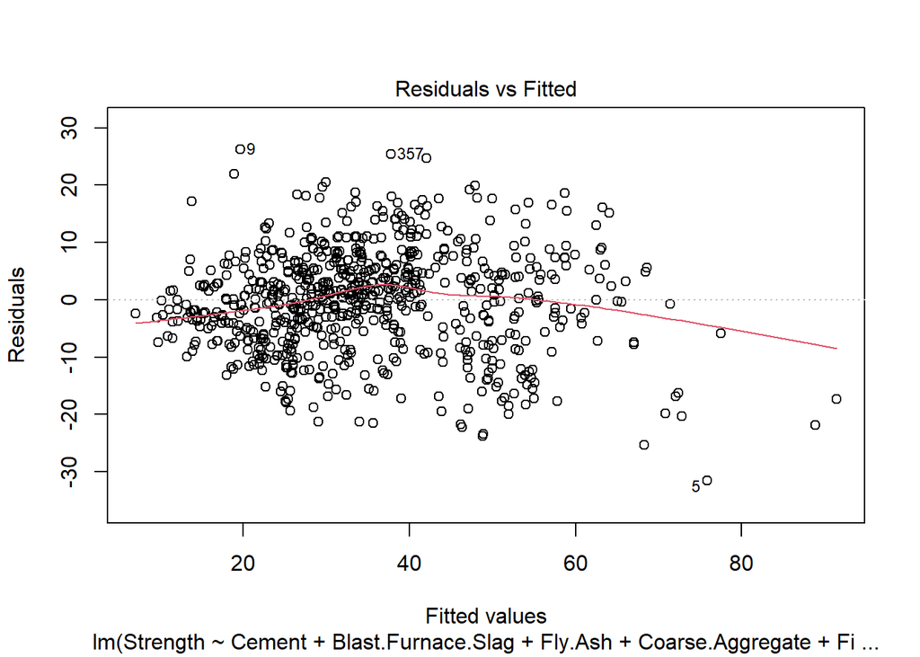

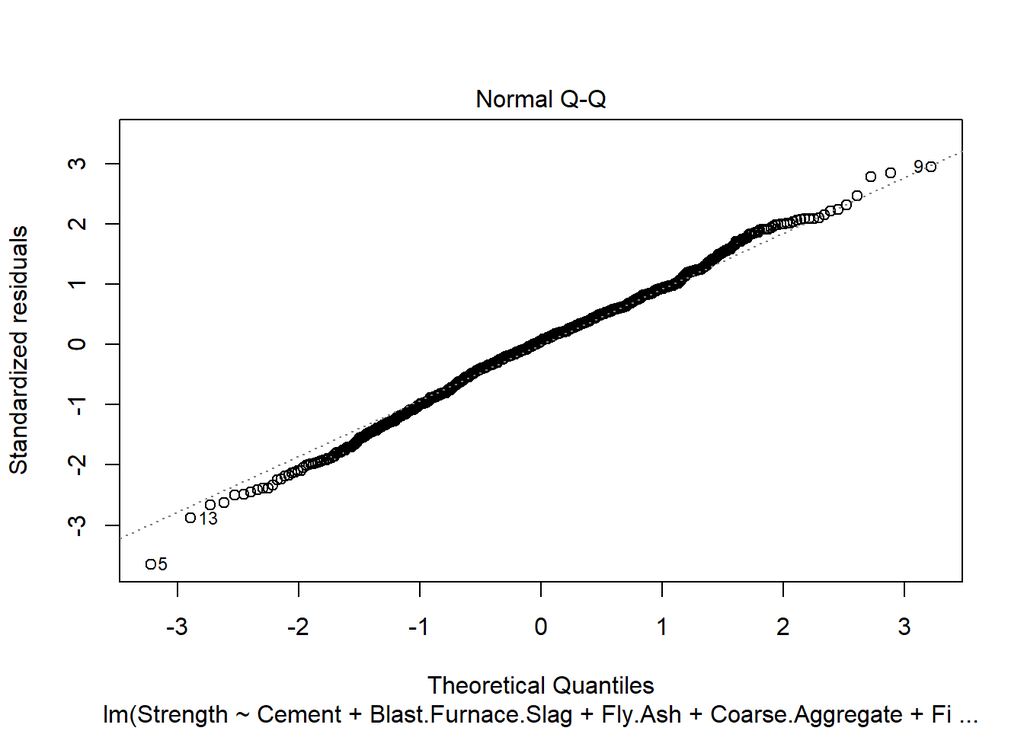

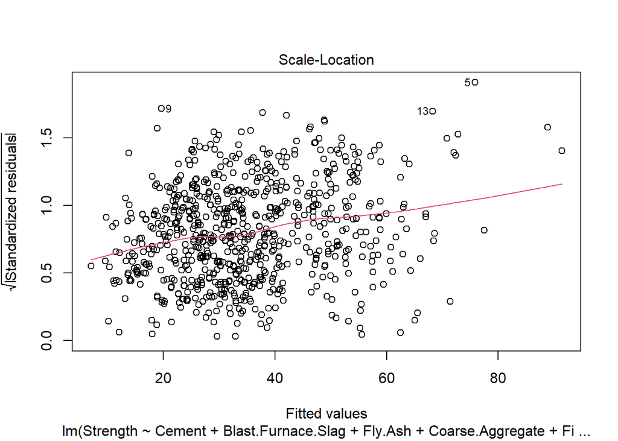

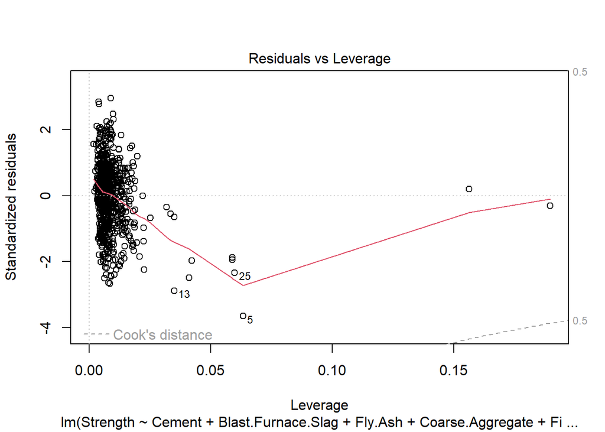

```r
plot(model3)
```

model3 ve model2’yi bir de AIC ve BIC değerleri üzerinden karşılaştırırsak:

```r
AIC(model2,k=8);AIC(model3,k=8)
```

```
## [1] 6343.816
```

```
## [1] 5664.335
```

```r
BIC(model2);BIC(model3)
```

```
## [1] 6333.529
```

```
## [1] 5653.579
```

Model3’un AIC ve BIC değerlerinin de model2’ye göre daha düşük yani daha iyi olduğu görülüyor.

Modelleri bir de test set üzerinden değerlendirirsek:

```r
predictions3<-predict(model3,testset2)

R2(predictions3,testset2$Strength)
```

```
## [1] 0.5444937
```

```r
RMSE(predictions3,testset2$Strength)
```

```
## [1] 12.1128
```

```r
MAE(predictions3,testset2$Strength)
```

```
## [1] 9.003629
```

```r
predictions2<-predict(model2,testset2)

R2(predictions2, testset2$Strength)
```

```
## [1] 0.5388243
```

```r
RMSE(predictions2, testset2$Strength)
```

```
## [1] 12.08446
```

```r
MAE(predictions2, testset2$Strength)
```

```
## [1] 9.456334
```

Sonuçlara bakıldığında model3 için testset2 üzerinden elde edilen R2 degeri model2’de elde edilen değere göre az da olsa artmıştır. Istediğimiz durumdur. RMSE değerinde ciddi bir değişim yoktur. model3 için testset2 üzerinden elde edilen MAE değeri model2’de elde edilen değere göre azalmıştır. Bu da bizim istediğimiz durumdur.

## k_fold Cross Validation

Aldığımız sonuçları doğrulamak için cross validation yapıp modelleri karşılaştıralım.

```r
library(caret)

train_kontrol<-trainControl(method='cv',number=10,verboseIter = TRUE)

model2_cv<- train(Strength~Cement+Blast.Furnace.Slag+Fly.Ash+Coarse.Aggregate+Fine.Aggregate+Age, data=trainset,
                  method='lm', trControl=train_kontrol)
model3_cv<- train(Strength~Cement+Blast.Furnace.Slag+Fly.Ash+Coarse.Aggregate+Fine.Aggregate+Age,data=trainsetrem,
                  method='lm', trControl=train_kontrol)
model2_cv
```

```
## Linear Regression
##
## 824 samples
##   6 predictor
##
## No pre-processing
## Resampling: Cross-Validated (10 fold)
## Summary of sample sizes: 741, 741, 743, 740, 741, 740, ...
## Resampling results:
##
##   RMSE      Rsquared   MAE
##   11.24193  0.5500707  8.61501
##
## Tuning parameter 'intercept' was held constant at a value of TRUE
```

```r
model3_cv
```

```
## Linear Regression
##
## 777 samples
##   6 predictor
##
## No pre-processing
## Resampling: Cross-Validated (10 fold)
## Summary of sample sizes: 699, 700, 700, 699, 699, 698, ...
## Resampling results:
##
##   RMSE      Rsquared   MAE
##   8.915609  0.6986237  7.030322
##
## Tuning parameter 'intercept' was held constant at a value of TRUE
```

Görüldüğü gibi model3’ün RMSE ve MAE değerleri model2’ye göre daha düşük, R2 değeri ise çok daha yüksek çıktı. model3’ün daha iyi bir model olduğuna karar verildi.

## Çoklu Bağlantı Sorunu

Bağımsız değişkenler arasında yüksek dereceli ilişkiler varsa çoklu bağlantı sorunu ortaya çıkar. Bağımsız değişkenler arasında ilişkinin olup olmadığını korelasyon sonuçlarından ve vif değerlerinden anlayabiliriz. vif değeri 10’dan büyük bir değişken varsa eğer orada çoklu baglantıdan şüpheleniyoruz. Önce vif değeri 10’dan büyük olan değişkeni modelden çıkarıp model sonuçlarını inceliyoruz. Herhangi bir iyileşme olmadıysa çıkarılan değişkeni modele tekrar dahil edip diğer bir değişkeni modelden çıkarıp model sonuçlarını inceliyoruz.

```r
library(car)
vif(model3)
```

```
##             Cement Blast.Furnace.Slag            Fly.Ash   Coarse.Aggregate
##           2.268396           2.470844           1.998336           1.460403
##     Fine.Aggregate                Age
##           1.620041           1.064846
```

Model3’teki tüm değişkenler için vif<10 olduğu için çoklu bağlantıdan şüphelenmiyoruz.

## İlişkili Hatalar

Bu adımda, hataların arasında ilişki olup olmadığını inceleyeceğiz. Hatalar arasında ilişki yoksa, hataların 0 doğrusu etrafında rastgele dağılmasını bekliyoruz. Grafik üzerinden kontrol edelim:

```r
n<-length(residuals(model3))
n
```

```
## [1] 777
```

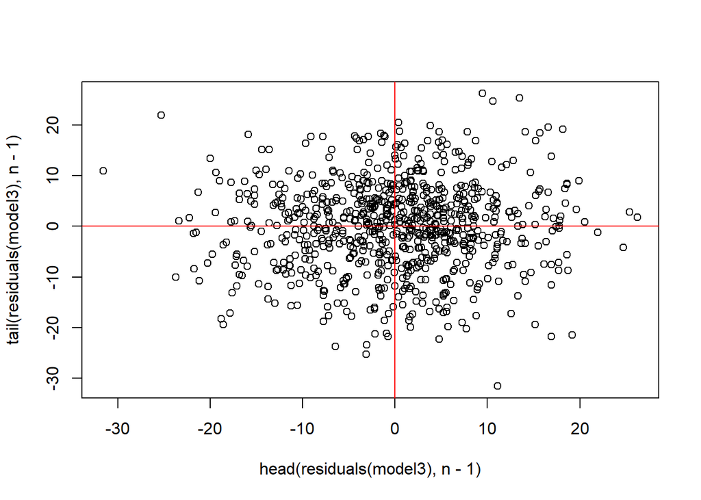

```r
plot(tail(residuals(model3),n-1) ~ head(residuals(model3),n-1))
abline(h=0, v=0, col="red")
```

Grafik incelendiğinde hatalar arasında ilişki olmadığı görülüyor. Yani otokorelasyon sorunu yok. Bu durumu bir de, hatalar arasında bir regresyon modeli kurup bu modelin anlamlılığına bakabiliriz. Grafik üzerinden verdiğimiz, otokorelasyon sorunu yok sonucunu doğrulaması için bu modelin anlamlı olmaması gerekiyor.

```r
summary(lm(tail(residuals(model3),n-1) ~ head(residuals(model3),n-1) -1))
```

```
##
## Call:
## lm(formula = tail(residuals(model3), n - 1) ~ head(residuals(model3),
##     n - 1) - 1)
##
## Residuals:
##     Min      1Q  Median      3Q     Max
## -31.961  -5.352   0.423   5.514  25.893
##
## Coefficients:
##                                Estimate Std. Error t value Pr(>|t|)
## head(residuals(model3), n - 1)  0.03526    0.03588   0.983    0.326
##
## Residual standard error: 8.889 on 775 degrees of freedom
## Multiple R-squared:  0.001245,   Adjusted R-squared:  -4.395e-05
## F-statistic: 0.9659 on 1 and 775 DF,  p-value: 0.326
```

Modelin sonuçları incelendiğinde p değerinin yüksek olmasından modelin anlamlı olmadığını anlıyoruz. Yani hatalar arasında doğrusal bir ilişki yok. Modelin sonuçlari grafik sonçularini doğruladı.